# Tianjin Stratified Incubation analysis

Jessica Stockdale, Caroline Colijn

28/02/2020

## Data

We use the same data as in the un-stratified analysis. Thanks to Dongxuan Chen and Louxin Zhang. These data are from three main sources:

- source1: http://wsjk.tj.gov.cn/col/col87/index.html#!uid=259&pageNum=1 (Tianjin health commission official website, for daily announcements)
- source2: https://weibo.com/u/2967529507 (Jinyun News, Tianjin offical local media weibo account, for patient symptom onset reference)
- source3: https://m.weibo.cn/status/IrrHI1FHm?jumpfrom=weibocom (another Tianjin local media weibo link, for mall cluster reference)

```r
tdata=read.csv("Tianjin135casesFeb22.csv",na.strings = "", stringsAsFactors = F)
tdata$symptom_onset=as.Date(tdata$symptom_onset, format = "%d/%m/%Y")
tdata$start_source=as.Date(tdata$start_source, format = "%d/%m/%Y")
tdata$end_source=as.Date(tdata$end_source,format = "%d/%m/%Y" )
tdata$confirm_date=as.Date(tdata$confirm_date,format = "%d/%m/%Y" )
str(tdata)
```

```
## 'data.frame':    135 obs. of  13 variables:
##  $ case_id         : chr  "TJ1" "TJ2" "TJ3" "TJ4" ...
##  $ gender          : chr  "F" "M" "F" "M" ...
##  $ age             : int  59 57 68 40 46 56 29 39 57 30 ...
##  $ symptom_onset   : Date, format: "2020-01-14" "2020-01-18" ...
##  $ symptom_type    : chr  "NA" "NA" "NA" "NA" ...
##  $ confirm_date    : Date, format: "2020-01-21" "2020-01-21" ...
##  $ Infection_source: chr  "Wuhan" "Wuhan; train import" "Wuhan" "Wuhan" ...
##  $ start_source    : Date, format: "2020-01-05" NA ...
##  $ end_source      : Date, format: "2020-01-14" "2020-01-18" ...
##  $ severity        : chr  "severe" "severe" "severe" "normal" ...
##  $ death           : chr  NA NA NA NA ...
##  $ recorrection    : chr  "added end source" "added end source" NA NA ...
##  $ notes           : chr  "sometimes Tianjin didn't mention the patient's severity" "Tianjin didn't tell which patient got cured, but they report death cases" "source1: http://wsjk.tj.gov.cn/col/col87/index.html#!uid=259&pageNum=1 (Tianjin health commission official webs"| __truncated__ "source2:…
```

## Incubation period, stratified by pre-/post- quarantine procedures in China

In this analysis we divide the data into 2 different datasets: from pre- and post- introduction of quarantine measures in China on January 23rd.

```r
goodii=which(!is.na(tdata$symptom_onset))
tdata$end_source[which(is.na(tdata$end_source))]=tdata$symptom_onset[which(is.na(tdata$end_source))]  # if no end exposure: set to symptom onset
tdata$end_source = pmin(tdata$end_source, tdata$symptom_onset) # if end exposure after onset, set to onset
tdata$start_source[which(is.na(tdata$start_source))]=as.Date("2019-12-31") # start date
tdata$maxIncTimes=tdata$symptom_onset-tdata$start_source
tdata$minIncTimes = tdata$symptom_onset-tdata$end_source
tdata$maxIncTimes
```

```
## Time differences in days
##   [1]   9  18  14  14  15  19  24   4  24   6  23  24  20  25  25  21  26
##  [18]   7   4  26  26  26  24  23  27  27 -23  19  11   9   5  23  30   8
##  [35]  30  28   9  NA   7  11  11  27   3  30  25  NA  23   6  15  11   7
##  [52]   7  31  27  32   8   9   6  33  20   9  30  32  32  14  11   6   9
##  [69]  34  22   6  32   3   6  33  12  27   3  11  10  31  34  34  35  27
##  [86]  31  13  28  35  33  36   7  34  37  32  38  40  32  NA  31  NA  NA
## [103]  16  NA  41  11  36  33  41  33   3  11  42  19  16  41  17  37  11
## [120]  43  42   6  NA  19  40  36  NA  11  NA  37  16  50  35  44  NA
```

```r
tdata$minIncTimes
```

```
## Time differences in days
##   [1]  0  0  0  0  0  0  1  1  7  4  0  0  0  6  2  0  7  7  4  7  9  3  3
##  [24] 12  8  5  0  0  7  5  2  3  6  0  4  3  8 NA  1  5  5  0  0  4  1 NA
##  [47]  5  6  9 11  7  0  8  3  0  8  9  6 14  0  0  0  0  0  0  8  0  9  0
##  [70]  0  6  0  3  6  0  1  0  3 11 10  0  0  0  0  0  0 13  0 12  0  0  7
##  [93]  0  0  0  0  0  0 NA  0 NA NA 14 NA  0  4  0  0  0  0  3 11  0  3  0
## [116]  0 17  0  4  0  0  6 NA 19  0  0 NA 11 NA  6 16 11  0  2 NA
```

```r
tdata$maxIncTimes[27] = 50 # for some reason this was coming up negative
```

We stratify the data according to whether each case was exposed before or after the quarantine measures were put in place on 23rd January 2020. Since the exposure times are not known, we estimated them using the estimated median incubation period of 8.554 days from the full data analysis. For each case, if the time of symptom appearance minus 8.554 days is prior to January 23rd, the are placed in the pre-quarantine dataset, and if not they are placed in the post-quarantine dataset.

For cases with no known symptom onset date, we take their case detection time - median(time between symptom onset and case detection) - 8.554 to determine which strata they are placed in instead. In actuality, we will remove cases with unknown symptom onset before using interval censoring to estimate the incubation period. However, we still place them in their respective dataset for now for completeness.

```r
symp_to_case <- as.numeric(median(as.Date(tdata$confirm_date, "%d/%m/%Y") - tdata$symptom_onset, na.rm=T)) # median 5
tdata1<-tdata[FALSE,]
tdata2<-tdata[FALSE,]
for (i in 1:135){
  if (!is.na(tdata$symptom_onset[i])){
    if ((tdata$symptom_onset[i]-8.554)<"2020-01-23"){
      tdata1 <- rbind(tdata1, tdata[i,])
   }else{
      tdata2 <- rbind(tdata2, tdata[i,])
   }
  }else{
    if ((as.Date(tdata$confirm_date[i], "%d/%m/%Y")-symp_to_case-8.554)<"2020-01-23"){
      tdata1 <- rbind(tdata1, tdata[i,])
   }else{
      tdata2 <- rbind(tdata2, tdata[i,])
   }

  }
}
str(tdata1)
```

```
## 'data.frame':    75 obs. of  15 variables:
##  $ case_id         : chr  "TJ1" "TJ2" "TJ3" "TJ4" ...
##  $ gender          : chr  "F" "M" "F" "M" ...
##  $ age             : int  59 57 68 40 46 56 29 39 57 30 ...
##  $ symptom_onset   : Date, format: "2020-01-14" "2020-01-18" ...
##  $ symptom_type    : chr  "NA" "NA" "NA" "NA" ...
##  $ confirm_date    : Date, format: "2020-01-21" "2020-01-21" ...
##  $ Infection_source: chr  "Wuhan" "Wuhan; train import" "Wuhan" "Wuhan" ...
##  $ start_source    : Date, format: "2020-01-05" "2019-12-31" ...
##  $ end_source      : Date, format: "2020-01-14" "2020-01-18" ...
##  $ severity        : chr  "severe" "severe" "severe" "normal" ...
##  $ death           : chr  NA NA NA NA ...
##  $ recorrection    : chr  "added end source" "added end source" NA NA ...
##  $ notes           : chr  "sometimes Tianjin didn't mention the patient's severity" "Tianjin didn't tell which patient got cured, but they report death cases" "source1: http://wsjk.tj.gov.cn/col/col87/index.html#!uid=259&pageNum=1 (Tianjin health commission official webs"| __truncated__ "source2:…
##  $ maxIncTimes     : 'difftime' num  9 18 14 14 ...
##   ..- attr(*, "units")= chr "days"
##  $ minIncTimes     : 'difftime' num  0 0 0 0 ...
##   ..- attr(*, "units")= chr "days"
```

```r
str(tdata2)
```

```
## 'data.frame':    60 obs. of  15 variables:
##  $ case_id         : chr  "TJ50" "TJ55" "TJ56" "TJ57" ...
##  $ gender          : chr  "M" "F" "F" "M" ...
##  $ age             : int  66 56 32 29 9 66 31 76 65 45 ...
##  $ symptom_onset   : Date, format: "2020-02-02" "2020-02-01" ...
##  $ symptom_type    : chr  "fever" "fatigue" "fever" "fever" ...
##  $ confirm_date    : Date, format: "2020-02-03" "2020-02-03" ...
##  $ Infection_source: chr  "shopping in mall" "TJ9; TJ21" "TJ38" "shopper in the mall" ...
##  $ start_source    : Date, format: "2020-01-22" "2019-12-31" ...
##  $ end_source      : Date, format: "2020-01-22" "2020-02-01" ...
##  $ severity        : chr  "normal" "normal" "normal" "normal" ...
##  $ death           : chr  "05/02/2020" NA NA NA ...
##  $ recorrection    : chr  NA NA NA NA ...
##  $ notes           : chr  NA NA NA NA ...
##  $ maxIncTimes     : 'difftime' num  11 32 8 9 ...
##   ..- attr(*, "units")= chr "days"
##  $ minIncTimes     : 'difftime' num  11 0 8 9 ...
##   ..- attr(*, "units")= chr "days"
```

We use survival analysis in the icenReg package to make parametric estimates, and we use the regular survival package to estimate the time to onset of symptoms.

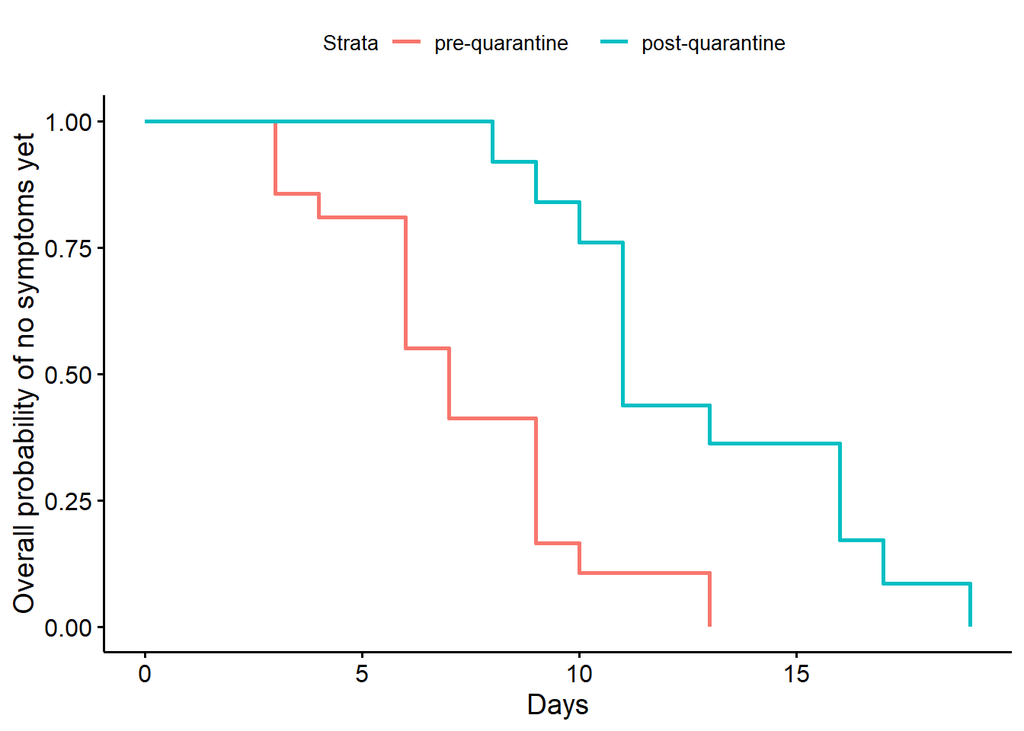

```r
myfit = list(preq = survfit(Surv(tdata1$minIncTimes, tdata1$maxIncTimes, type="interval2")~1, data=tdata1), postq = survfit(Surv(tdata2$minIncTimes, tdata2$maxIncTimes, type="interval2")~1, data=tdata2))

ggsurvplot(
  fit=myfit,
  xlab="Days",
  ylab = "Overall probability of no symptoms yet",  combine = TRUE, legend.labs=c("pre-quarantine   ", "post-quarantine "))
```

```r
## Check if the split is perfect down the middle: it's not e.g. there's a 2 day in tdata2 and a 50 day in tdata1. This is reassuring
```

The median is about 7 days pre-lockdown and 11 days post-lockdown. For a parametric estimate we remove any remaining NAs and use interval censoring, because we know only that exposure was some time between the minimum and maximum possible values.

```r
reddata1=tdata1[which(!is.na(tdata1$minIncTimes)),] # NAs always occur for max and min  and symptom_onset together
myfit1 = ic_par(Surv(reddata1$minIncTimes, reddata1$maxIncTimes,type="interval2")~1, data = reddata1,dist="weibull")

reddata2=tdata2[which(!is.na(tdata2$minIncTimes)),] # NAs always occur for max and min together
myfit2 = ic_par(Surv(reddata2$minIncTimes, reddata2$maxIncTimes,type="interval2")~1, data = reddata2,dist="weibull")
```

The log of the pre-quarantine shape parameter is 1.007 $\pm$ 0.157, which gives a shape parameter of 2.737 in the range (2.012, 3.725).

The log of the post-quarantine shape parameter is 1.373 $\pm$ 0.201, which gives a shape parameter of 3.947 in the range (2.662, 5.853).

Similarly the log of the pre-quarantine scale parameter is 2.059 $\pm$ 0.069, which gives a scale parameter of 7.84 in the range (6.851, 8.972).

Finally, the log of the post-quarantine scale parameter is 2.613 $\pm$ 0.066, which gives a scale parameter of 13.636 in the range (11.987, 15.51).

```r
incqs1=getFitEsts(myfit1, newdata = NULL, p=c(0.025,0.05, 0.25, 0.5, 0.75,0.95,0.975)) #
incqs2=getFitEsts(myfit2, newdata = NULL, p=c(0.025,0.05, 0.25, 0.5, 0.75,0.95,0.975))
```

The median is 6.857 days and the 95th percentile estimate is 11.705 pre-quarantine, and equivalently median 12.426 days and 95th percentile 18.005 post-quarantine.

Here are some plots of the estimated distribution together with the empirical survival curve from the data.

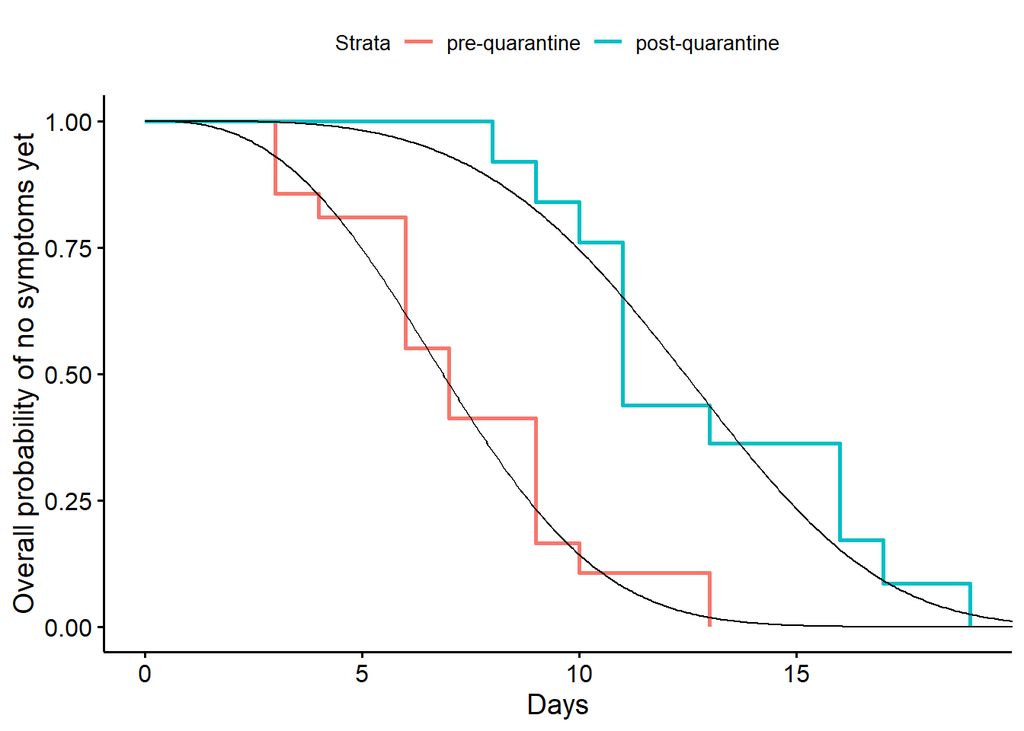

```r
days=seq(0,20,by=0.05)
ggs = ggsurvplot(
  fit=myfit,
  xlab="Days",  ylab = "Overall probability of no symptoms yet", combine = TRUE,    legend.labs=c("pre-quarantine", "post-quarantine"))
tmp=data.frame(days=days,  fitsurv=1-pweibull(days, shape = exp(myfit1$coefficients[1]),
                      scale = exp(myfit1$coefficients[2])))
tmp2=data.frame(days=days,  fitsurv=1-pweibull(days, shape = exp(myfit2$coefficients[1]),
                      scale = exp(myfit2$coefficients[2])))
ggs$plot + geom_line(data = tmp, aes(x = days, y = fitsurv)) + geom_line(data = tmp2, aes(x = days, y = fitsurv))
```